# Problem Set 3

Gov 1005 Spring 2020

Read [how we grade problem sets](https://www.davidkane.info/post/2019-08-31-problem-sets-and-exams/).

**Objectives for this problem set:**

- Students will apply the Rubin Causal Model to example data
- Students will develop skills for manipulating strings and factor variables
- Students will demonstrate their ability to retrieve data from multiple sources (csv, wikipedia)

## Getting Data Into R

We’re going to use some data from ``Bread and Circuses: Sports and Public Opinion in China’’, which attempts to understand whether sports can increase the favorable attitudes of citizens toward their government. The authors recruited survey participants in two Chinese cities to answer questions about their satisfaction with the government. The “treatment” group watched a 2 minute video about Chinese athletes succeeding in the international arena before answering the questions.

1. First, create a subdirectory in your project called `raw-data`. Notice that this repo contains the spreadsheet `xian_data.csv`. Move this in your raw-data subdirectory. (Remember to push and commit these changes!)
2. Read in your csv using `read_csv`. Make sure to clean your data. For example, make te colimn names easy to work with, as we did in class. Set the “undefined” and missing values as NA.

## Madlibs

1. X respondents are in the treatment group.
2. Among respondents from the treatment group, the government has an average X rating.
3. The most common rating for the government’s handling of traffic is X.
4. X respondents have given the government a 10 rating overall *or* on demolitions *or* on traffic.
5. But only X gave the government a 10 rating overall *and* on demolitions *and* on traffic.

The variable ‘news_source’ asks respondents to list which news sources they get their news from. Some respondents answered more than one option, so their answer lists a number of letters together. A means “Television”, B means “Newspapers”, C means “Radio”, etc

6. The number of respondents who get their news from Television is X
7. Of the 4 different locations where the respondents were surveyed, the following two locations end with “square”: X,X

## Data Wrangling

1)Subset the data so that you’re just working with the variables `eval_gov_overall`, `eval_gov_traffic`, `eval_gov_demo`, and the respondent id `respondent`. Although these variables are evaluated on the same scale, they each have their own column. Make us a `gt` table like this of the first 10 observations of these four variables in its current, untidy format.

Untidy Data

| Respondent Number | Evaluations of Government Performance Overall | Evaluations of Government Performance Traffic | Evaluations of Government Performance Demolitions |
| --- | --- | --- | --- |
| 1 | 7 | 5 | 4 |
| 2 | 5 | 8 | 8 |
| 3 | 3 | 1 | 2 |
| 4 | NA | NA | NA |
| 5 | 9 | 8 | 8 |
| 6 | 6 | 6 | 6 |
| 7 | 8 | 8 | 8 |
| 8 | 5 | 5 | 1 |
| 9 | 2 | 6 | 2 |
| 10 | 5 | 9 | 4 |

Use a pivot command to put the data into tidy format. Make a similar table, but in tidy format (see below). Notice how the size and shape of the table that you need to show 10 respondents’ data changes when you go from untidy to tidy format.

Tidy Data

| Respondent Number | Type of Evaluation | Performance Rating |
| --- | --- | --- |
| 1 | Overall | 7 |
| 1 | Traffic | 5 |
| 1 | Demo | 4 |
| 2 | Overall | 5 |
| 2 | Traffic | 8 |
| 2 | Demo | 8 |
| 3 | Overall | 3 |
| 3 | Traffic | 1 |
| 3 | Demo | 2 |
| 4 | Overall | NA |
| 4 | Traffic | NA |
| 4 | Demo | NA |
| 5 | Overall | 9 |
| 5 | Traffic | 8 |
| 5 | Demo | 8 |
| 6 | Overall | 6 |
| 6 | Traffic | 6 |
| 6 | Demo | 6 |
| 7 | Overall | 8 |
| 7 | Traffic | 8 |
| 7 | Demo | 8 |
| 8 | Overall | 5 |
| 8 | Traffic | 5 |
| 8 | Demo | 1 |
| 9 | Overall | 2 |
| 9 | Traffic | 6 |
| 9 | Demo | 2 |
| 10 | Overall | 5 |
| 10 | Traffic | 9 |
| 10 | Demo | 4 |

Potential Outcomes<sup>1</sup>

| Respondent | Treatment | Control | Potential Outcomes Under Control | Potential Outcomes Under Treatment |
| --- | --- | --- | --- | --- |
| 106 | 1 | 0 | ? | 8 |
| 107 | 0 | 1 | 8 | ? |
| 108 | 1 | 0 | ? | 6 |
| 109 | 0 | 1 | 5 | ? |
| 110 | 1 | 0 | ? | 6 |
| 111 | 0 | 1 | 6 | ? |
| 112 | 0 | 1 | 5 | ? |
| 113 | 1 | 0 | ? | 8 |
| 114 | 0 | 1 | 5 | ? |
| 115 | 1 | 0 | ? | 1 |
| 116 | 1 | 0 | ? | 5 |

<sup>*1*</sup> Treatment is a 2 minute video about Chinese sports performance

3. We’d like to know something about the demographics of our respondents. Go to the Gov 1005 Canvas page and find the `files` tab. Download the `demographics.Rdata` dataset from the `ps_3` folder. Create a new directory called `r-data` in this repo and move the demographics file here. (Remember to commit these changes). Load the file and join it to your existing data.

Highest Evaluators of Government Performance on Traffic:<sup>1</sup>

Among Treated Individuals

| Respondent | Evaluate Government Performance | Age | Gender |
| --- | --- | --- | --- |
| 22 | 10 | 28 | Male |
| 82 | 10 | 24 | Female |
| 99 | 10 | 21 | Female |
| 10 | 9 | 35 | Male |
| 13 | 9 | 17 | Male |

<sup>*1*</sup> Evaluation on Scale from 1 to 10

4. Replicate this plot, which shows evaluations of government performance based on treatment status and education. You may want to consult the book for tips on reordering factors.

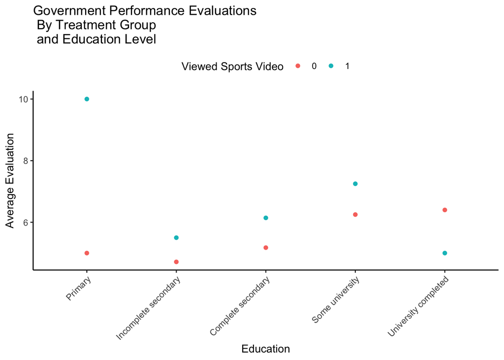

5. Now, try your hand at using the `rvest` package, which we can use to get tables from the internet. Using [this](https://en.wikipedia.org/wiki/2008_Summer_Olympics) wikipedia page, grab the table of country gold medals and make a plot like this:

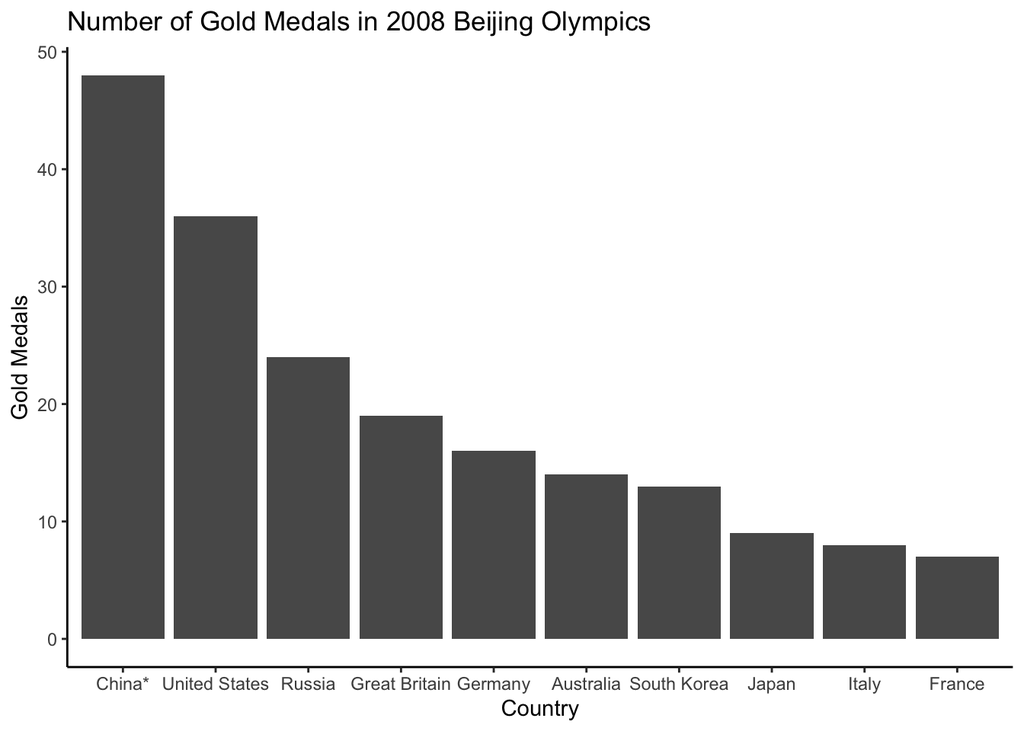